# Geographically Weighted Regression

Jeremy R. Porter

Spring 2019

#### First, let’s set our working directory for any files we may write from R….

```r
knitr::opts_chunk$set(
    echo = TRUE,
    message = TRUE,
    warning = TRUE
)
setwd("C:/Users/Jeremy/Desktop/spring2019/Adv_GIS/week7")
```

#### To begin, I am going to require the `RPostgres` package and read in the `prop_val_sample_oc` table from our `lab4` schema to measure the value of the home at the point of sale and at the baseline year of 2005. Next, I want to read in the `mhhw_slosh_sample` table from the `lab6` schema to measure the inundation levels from the hurricane scenarios and the difference between the water table at high tide and the elevation of the home. Finally, I want to read in the `oc_assessor` data from the `lab7` schema (setup tonight with the file I gave you) to measure a selected set of housing characteristics as pricing controls for our model.

```r
require(RPostgres)

conn <- dbConnect(RPostgres::Postgres(), dbname = 'advanced_gis',
                  host = 'localhost', # i.e. 'your computer'
                  port = 5432, # or any other port specified by your DBA
                  user = 'postgres',
                  password = 'jeremy')


options(digits = 10)

oc_sale_data <- dbFetch(dbSendQuery(conn, "SELECT * FROM lab4.prop_val_sample_oc"))

oc_prop_flood <- dbFetch(dbSendQuery(conn, "SELECT * FROM lab6.mhhw_slosh_sample"))

oc_assessor <- dbFetch(dbSendQuery(conn, "SELECT * FROM lab7.oc_assessor"))
```

#### In the next chunk of code, I want to explore the variables I brought into the lab and then convert and variables no in their proper form (character, numeric, etc.) to the form necessary to include in our analysis. I use the `summary` command as a quick way to do this. From the results, the `oc_prop_flood` object looks good. However, the other two objects have a lot of variables that are ultimately going to be read in to our regression models as `type = character` so here we identify those variables and use the `sapply` function to convert them to `type = numeric` via the `as.numeric` argument.

```r
summary(oc_prop_flood)
```

```
##        id           geom                c1_high            c2_high
##  Min.   :   1   Length:4086          Min.   : 0.00000   Min.   : 0.00000
##  1st Qu.:1022   Class :pq_geometry   1st Qu.: 4.20000   1st Qu.: 3.80000
##  Median :2044   Mode  :character     Median :99.90000   Median : 9.40000
##  Mean   :2043                        Mean   :68.88111   Mean   :47.52472
##  3rd Qu.:3065                        3rd Qu.:99.90000   3rd Qu.:99.90000
##  Max.   :4086                        Max.   :99.90000   Max.   :99.90000
##     c3_high            c4_high           elev_water
##  Min.   : 0.20000   Min.   : 0.00000   Min.   :-24.56000
##  1st Qu.: 5.90000   1st Qu.:10.40000   1st Qu.: -3.44794
##  Median :10.70000   Median :15.20000   Median :  8.78169
##  Mean   :23.21038   Mean   :25.03245   Mean   : 20.49447
##  3rd Qu.:14.60000   3rd Qu.:18.60000   3rd Qu.: 30.76541
##  Max.   :99.90000   Max.   :99.90000   Max.   :138.85104
```

```r
summary(oc_sale_data)
```

```
##        id            pr_sq_ft             fsid
##  Min.   :   1.00   Length:4086        Length:4086
##  1st Qu.:1022.25   Class :character   Class :character
##  Median :2043.50   Mode  :character   Mode  :character
##  Mean   :2043.50
##  3rd Qu.:3064.75
##  Max.   :4086.00
##    saleyear              x                  y
##  Length:4086        Length:4086        Length:4086
##  Class :character   Class :character   Class :character
##  Mode  :character   Mode  :character   Mode  :character
##
##
##
##   samp_pr05             geom
##  Length:4086        Length:4086
##  Class :character   Class :pq_geometry
##  Mode  :character   Mode  :character
##
##
##
```

```r
cols.num <- c("pr_sq_ft","saleyear","x","y","samp_pr05")
oc_sale_data[cols.num] <- sapply(oc_sale_data[cols.num],as.numeric)

summary(oc_assessor)
```

```
##        id            fsid             tractfp          arealotacres
##  Min.   :    1   Length:13857       Length:13857       Length:13857
##  1st Qu.: 3465   Class :character   Class :character   Class :character
##  Median : 6929   Mode  :character   Mode  :character   Mode  :character
##  Mean   : 6929
##  3rd Qu.:10393
##  Max.   :13857
##  areabuilding       bedroomscount       yearbuilt
##  Length:13857       Length:13857       Length:13857
##  Class :character   Class :character   Class :character
##  Mode  :character   Mode  :character   Mode  :character
##
##
##
##   unitscount         beachprox           fld_zone
##  Length:13857       Length:13857       Length:13857
##  Class :character   Class :character   Class :character
##  Mode  :character   Mode  :character   Mode  :character
##
##
##
##   near_golf           singfam               x
##  Length:13857       Length:13857       Length:13857
##  Class :character   Class :character   Class :character
##  Mode  :character   Mode  :character   Mode  :character
##
##
##
##       y
##  Length:13857
##  Class :character
##  Mode  :character
##
##
##
```

```r
cols.num2 <- c("arealotacres","areabuilding","x","y","bedroomscount","yearbuilt",
               "unitscount","beachprox","near_golf","singfam")
oc_assessor[cols.num2] <- sapply(oc_assessor[cols.num2],as.numeric)

summary(oc_sale_data)
```

```
##        id             pr_sq_ft             fsid
##  Min.   :   1.00   Min.   : 10.50144   Length:4086
##  1st Qu.:1022.25   1st Qu.:112.84987   Class :character
##  Median :2043.50   Median :147.20912   Mode  :character
##  Mean   :2043.50   Mean   :153.37387
##  3rd Qu.:3064.75   3rd Qu.:186.57313
##  Max.   :4086.00   Max.   :530.82192
##
##     saleyear              x                   y
##  Min.   :2005.000   Min.   :-75.29906   Min.   :38.21253
##  1st Qu.:2007.000   1st Qu.:-75.16946   1st Qu.:38.33430
##  Median :2011.000   Median :-75.15318   Median :38.37130
##  Mean   :2010.863   Mean   :-75.15863   Mean   :38.36193
##  3rd Qu.:2014.000   3rd Qu.:-75.13754   3rd Qu.:38.38880
##  Max.   :2018.000   Max.   :-75.06681   Max.   :38.45087
##
##    samp_pr05             geom
##  Min.   : 40.34723   Length:4086
##  1st Qu.:174.66073   Class :pq_geometry
##  Median :186.28590   Mode  :character
##  Mean   :190.76477
##  3rd Qu.:204.54537
##  Max.   :467.18155
##  NA's   :37
```

```r
summary(oc_assessor)
```

```
##        id            fsid             tractfp
##  Min.   :    1   Length:13857       Length:13857
##  1st Qu.: 3465   Class :character   Class :character
##  Median : 6929   Mode  :character   Mode  :character
##  Mean   : 6929
##  3rd Qu.:10393
##  Max.   :13857
##   arealotacres          areabuilding        bedroomscount
##  Min.   :  0.0000000   Min.   :   288.000   Min.   :0
##  1st Qu.:  0.0826446   1st Qu.:  1200.000   1st Qu.:0
##  Median :  0.2066116   Median :  1600.000   Median :0
##  Mean   :  1.4761984   Mean   :  2037.902   Mean   :0
##  3rd Qu.:  0.3429293   3rd Qu.:  2230.000   3rd Qu.:0
##  Max.   :343.0100092   Max.   :183904.000   Max.   :0
##    yearbuilt          unitscount          beachprox
##  Min.   :1740.000   Min.   :0.0000000   Min.   :0.0000000
##  1st Qu.:1976.000   1st Qu.:1.0000000   1st Qu.:0.0000000
##  Median :1991.000   Median :1.0000000   Median :1.0000000
##  Mean   :1984.297   Mean   :0.8434004   Mean   :0.5945731
##  3rd Qu.:2003.000   3rd Qu.:1.0000000   3rd Qu.:1.0000000
##  Max.   :2016.000   Max.   :3.0000000   Max.   :1.0000000
##    fld_zone           near_golf           singfam
##  Length:13857       Min.   :0.000000   Min.   :0.0000000
##  Class :character   1st Qu.:0.000000   1st Qu.:1.0000000
##  Mode  :character   Median :0.000000   Median :1.0000000
##                     Mean   :0.148084   Mean   :0.7889875
##                     3rd Qu.:0.000000   3rd Qu.:1.0000000
##                     Max.   :1.000000   Max.   :1.0000000
##        x                   y
##  Min.   :-75.62646   Min.   :38.00189
##  1st Qu.:-75.19846   1st Qu.:38.32373
##  Median :-75.14768   Median :38.36842
##  Mean   :-75.18408   Mean   :38.33566
##  3rd Qu.:-75.10817   3rd Qu.:38.39432
##  Max.   :-75.05000   Max.   :38.45119
```

#### Next, I am going to explore the ordering of the `id` variables for the `oc_prop_flood` and the `oc_sale_data` to make sure that they are in the same order as when we created them (they are) and then use the `cbind` function to create a new object `oc_full` by binding the two together column-wise. When I explore the data I can see that, at least in my case, the hurricane scenarios still have `99.9` to represent no inundation so I am going recode that to `0` for the entire `oc_full` object anywhere `99.9` exists. You want to be careful with this approach as it could change other variables `==99.9` to `0` as well, but in our case its fine for this set of data. Finally, because `GWR` models can not handle missing data, I am going to recode the missing values for the baseline 2005 price `(samp_pr05)` to the average for that variable `(mean = 190.76477)`.

```r
head(oc_prop_flood$id)
```

```
## integer64
## [1] 1 2 3 4 5 6
```

```r
head(oc_sale_data$id)
```

```
## [1] 1 2 3 4 5 6
```

```r
oc_full<-cbind(oc_sale_data,oc_prop_flood)
head(oc_full)
```

```
##   id    pr_sq_ft         fsid saleyear            x           y
## 1  1 436.4518976 240472086092     2005 -75.13892612 38.39201732
## 2  2 436.4518976 240472086092     2005 -75.13892612 38.39201732
## 3  3 225.6944444 240472086093     2006 -75.16592039 38.38285553
## 4  4 124.7106481 240472086093     2011 -75.16592039 38.38285553
## 5  5 124.7106481 240472086093     2011 -75.16592039 38.38285553
## 6  6 211.2369338 240472086097     2006 -75.16286912 38.36604107
##     samp_pr05                                               geom id
## 1 336.5765422 0101000020AD100000EE0D5D2AE4C852C00DE8A79F2D324340  1
## 2 336.5765422 0101000020AD100000EE0D5D2AE4C852C00DE8A79F2D324340  2
## 3 185.9074214 0101000020AD1000009C8A8D709ECA52C04A03F66801314340  3
## 4 185.9074214 0101000020AD1000009C8A8D709ECA52C04A03F66801314340  4
## 5 185.9074214 0101000020AD1000009C8A8D709ECA52C04A03F66801314340  5
## 6 180.5022377 0101000020AD100000F1529D726CCA52C050EC0E6FDA2E4340  6
##                                                                   geom
## 1 0104000020E6100000010000000101000000EE0D5D2AE4C852C00DE8A79F2D324340
## 2 0104000020E6100000010000000101000000EE0D5D2AE4C852C00DE8A79F2D324340
## 3 0104000020E61000000100000001010000009C8A8D709ECA52C04A03F66801314340
## 4 0104000020E61000000100000001010000009C8A8D709ECA52C04A03F66801314340
## 5 0104000020E61000000100000001010000009C8A8D709ECA52C04A03F66801314340
## 6 0104000020E6100000010000000101000000F1529D726CCA52C050EC0E6FDA2E4340
##   c1_high c2_high c3_high c4_high elev_water
## 1     1.4     3.7    13.8    18.0  -10.65371
## 2     1.4     3.7    13.8    18.0  -10.65371
## 3    99.9    99.9     4.6     9.1   27.14174
## 4    99.9    99.9     4.6     9.1   27.14174
## 5    99.9    99.9     4.6     9.1   27.14174
## 6    99.9    99.9     4.2     8.7   31.84341
```

```r
summary(oc_full)
```

```
##        id             pr_sq_ft             fsid
##  Min.   :   1.00   Min.   : 10.50144   Length:4086
##  1st Qu.:1022.25   1st Qu.:112.84987   Class :character
##  Median :2043.50   Median :147.20912   Mode  :character
##  Mean   :2043.50   Mean   :153.37387
##  3rd Qu.:3064.75   3rd Qu.:186.57313
##  Max.   :4086.00   Max.   :530.82192
##
##     saleyear              x                   y
##  Min.   :2005.000   Min.   :-75.29906   Min.   :38.21253
##  1st Qu.:2007.000   1st Qu.:-75.16946   1st Qu.:38.33430
##  Median :2011.000   Median :-75.15318   Median :38.37130
##  Mean   :2010.863   Mean   :-75.15863   Mean   :38.36193
##  3rd Qu.:2014.000   3rd Qu.:-75.13754   3rd Qu.:38.38880
##  Max.   :2018.000   Max.   :-75.06681   Max.   :38.45087
##
##    samp_pr05             geom                   id
##  Min.   : 40.34723   Length:4086          Min.   :   1
##  1st Qu.:174.66073   Class :pq_geometry   1st Qu.:1022
##  Median :186.28590   Mode  :character     Median :2044
##  Mean   :190.76477                        Mean   :2043
##  3rd Qu.:204.54537                        3rd Qu.:3065
##  Max.   :467.18155                        Max.   :4086
##  NA's   :37
##      geom                c1_high            c2_high
##  Length:4086          Min.   : 0.00000   Min.   : 0.00000
##  Class :pq_geometry   1st Qu.: 4.20000   1st Qu.: 3.80000
##  Mode  :character     Median :99.90000   Median : 9.40000
##                       Mean   :68.88111   Mean   :47.52472
##                       3rd Qu.:99.90000   3rd Qu.:99.90000
##                       Max.   :99.90000   Max.   :99.90000
##
##     c3_high            c4_high           elev_water
##  Min.   : 0.20000   Min.   : 0.00000   Min.   :-24.56000
##  1st Qu.: 5.90000   1st Qu.:10.40000   1st Qu.: -3.44794
##  Median :10.70000   Median :15.20000   Median :  8.78169
##  Mean   :23.21038   Mean   :25.03245   Mean   : 20.49447
##  3rd Qu.:14.60000   3rd Qu.:18.60000   3rd Qu.: 30.76541
##  Max.   :99.90000   Max.   :99.90000   Max.   :138.85104
##
```

```r
oc_full[oc_full==99.9]<-0
oc_full$samp_pr05 <- ifelse(is.na(oc_full$samp_pr05),
                            190.76477, oc_full$samp_pr05)
summary(oc_full)
```

```
##        id             pr_sq_ft             fsid
##  Min.   :   1.00   Min.   : 10.50144   Length:4086
##  1st Qu.:1022.25   1st Qu.:112.84987   Class :character
##  Median :2043.50   Median :147.20912   Mode  :character
##  Mean   :2043.50   Mean   :153.37387
##  3rd Qu.:3064.75   3rd Qu.:186.57313
##  Max.   :4086.00   Max.   :530.82192
##     saleyear              x                   y
##  Min.   :2005.000   Min.   :-75.29906   Min.   :38.21253
##  1st Qu.:2007.000   1st Qu.:-75.16946   1st Qu.:38.33430
##  Median :2011.000   Median :-75.15318   Median :38.37130
##  Mean   :2010.863   Mean   :-75.15863   Mean   :38.36193
##  3rd Qu.:2014.000   3rd Qu.:-75.13754   3rd Qu.:38.38880
##  Max.   :2018.000   Max.   :-75.06681   Max.   :38.45087
##    samp_pr05             geom                   id
##  Min.   : 40.34723   Length:4086          Min.   :   0
##  1st Qu.:174.66073   Class :pq_geometry   1st Qu.:1022
##  Median :186.86438   Mode  :character     Median :2044
##  Mean   :190.76477                        Mean   :2043
##  3rd Qu.:203.94661                        3rd Qu.:3065
##  Max.   :467.18155                        Max.   :4086
##      geom                c1_high           c2_high
##  Length:4086          Min.   :0.00000   Min.   : 0.000000
##  Class :pq_geometry   1st Qu.:0.00000   1st Qu.: 0.000000
##  Mode  :character     Median :0.00000   Median : 0.500000
##                       Mean   :1.03419   Mean   : 2.244542
##                       3rd Qu.:1.60000   3rd Qu.: 4.100000
##                       Max.   :6.90000   Max.   :12.000000
##     c3_high             c4_high           elev_water
##  Min.   : 0.000000   Min.   : 0.00000   Min.   :-24.56000
##  1st Qu.: 3.800000   1st Qu.: 8.70000   1st Qu.: -3.44794
##  Median : 9.600000   Median :13.90000   Median :  8.78169
##  Mean   : 7.905091   Mean   :11.82981   Mean   : 20.49447
##  3rd Qu.:13.100000   3rd Qu.:17.60000   3rd Qu.: 30.76541
##  Max.   :17.500000   Max.   :22.50000   Max.   :138.85104
```

#### Now let’s require the `sp` package and convert our `oc_full` object and the `oc_assessor` object to a `SpatialPointsDataFrame` by setting `x+y` as the spatial coordinates via the `coordinates` function and projecting the `CRS` to `4269` via the `proj4string` function. I’m going to `plot` them both here to make sure they look reasonable. As you can see from the plot (and the object size in the environment) the `oc_assessor` data contains information for many more cases than we have sales data for… so let’s use the `merge` function to join the two object’s dataframes by the common `fsid` id variable. We now have a new object `(oc_join)` that represents the sales data, the risk of flooding, and the home characteristics for all recent sales in Ocean City, MD.

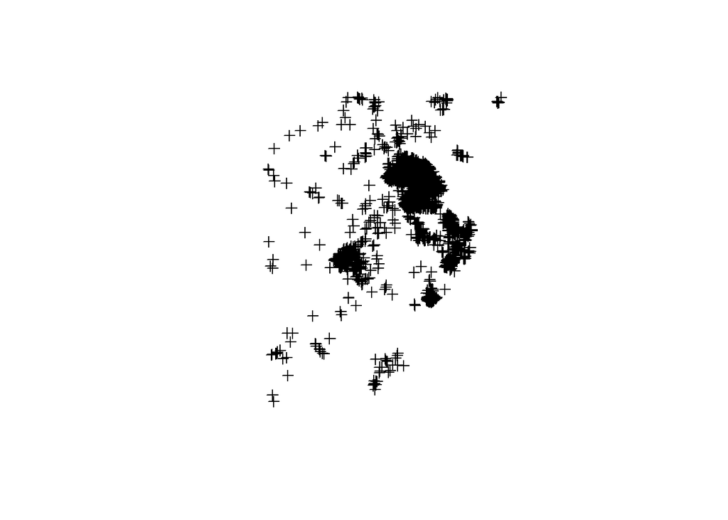

```r
require(sp)
coordinates(oc_full)=~x+y
proj4string(oc_full)=CRS("+init=epsg:4269")
plot(oc_full)
```

[figure not shown]

```r
coordinates(oc_assessor)=~x+y
proj4string(oc_assessor)=CRS("+init=epsg:4269")
plot(oc_assessor)
```

```r
oc_join <- merge(oc_full@data, oc_assessor@data, by="fsid")
head(oc_join)
```

```
##           fsid id.x    pr_sq_ft saleyear   samp_pr05
## 1 240472086092    1 436.4518976     2005 336.5765422
## 2 240472086092    2 436.4518976     2005 336.5765422
## 3 240472086093    3 225.6944444     2006 185.9074214
## 4 240472086093    4 124.7106481     2011 185.9074214
## 5 240472086093    5 124.7106481     2011 185.9074214
## 6 240472086097    6 211.2369338     2006 180.5022377
##                                                 geom id.1
## 1 0101000020AD100000EE0D5D2AE4C852C00DE8A79F2D324340    1
## 2 0101000020AD100000EE0D5D2AE4C852C00DE8A79F2D324340    2
## 3 0101000020AD1000009C8A8D709ECA52C04A03F66801314340    3
## 4 0101000020AD1000009C8A8D709ECA52C04A03F66801314340    4
## 5 0101000020AD1000009C8A8D709ECA52C04A03F66801314340    5
## 6 0101000020AD100000F1529D726CCA52C050EC0E6FDA2E4340    6
##                                                                 geom.1
```

[output cut: 27 more lines]

#### For today’s lab we are going to explore the non-stationarity of relationships associated with risk of flooding from tidal events `(operationalized by elevation vs. water table)` and the trend in home sales over our study period. To do that, we need to require the `spgwr` package, but first lets also explore the relationships as a linear function using `lm`. In the first model, I am just going to add the home characteristics as a “control model”. From this first model and in relation to the price per square foot at sale `(pr_sq_ft)`, it appears that the size of the property `(arealotacres)` is positively associated with price, the size of the building `(areabuilding)` is negatively associated with price, the year the property was built `(yearbuilt)` is positively associated with price, the number of units in the property `(unitscount)` is positively assocaited with price, and single family home status `(singfam)` is negatively associated with price. With just property characteristics in the model, the R-Square indicates that only about `2%` of the variation in sale price can be accounted for.

```r
######GWR model
#install.packages("spgwr")
library(spgwr)

names(oc_join)
```

```
##  [1] "fsid"          "id.x"          "pr_sq_ft"      "saleyear"
##  [5] "samp_pr05"     "geom"          "id.1"          "geom.1"
##  [9] "c1_high"       "c2_high"       "c3_high"       "c4_high"
## [13] "elev_water"    "id.y"          "tractfp"       "arealotacres"
## [17] "areabuilding"  "bedroomscount" "yearbuilt"     "unitscount"
## [21] "beachprox"     "fld_zone"      "near_golf"     "singfam"
```

```r
lm_homechar <- lm(pr_sq_ft ~ arealotacres + areabuilding +
           yearbuilt + unitscount + singfam, data=oc_join)
summary(lm_homechar)
```

```
##
## Call:
## lm(formula = pr_sq_ft ~ arealotacres + areabuilding + yearbuilt +
##     unitscount + singfam, data = oc_join)
##
## Residuals:
##        Min         1Q     Median         3Q        Max
## -147.14590  -40.82762   -6.83608   32.76573  387.99163
##
## Coefficients:
##                   Estimate    Std. Error  t value   Pr(>|t|)
## (Intercept)  -2.603750e+02  1.087217e+02 -2.39488 0.01667084 *
## arealotacres  1.003556e-01  3.514538e-01  0.28554 0.77524163
## areabuilding -2.572789e-03  3.786425e-04 -6.79477 1.2419e-11 ***
## yearbuilt     2.070579e-01  5.473281e-02  3.78307 0.00015713 ***
## unitscount    1.506128e+01  3.879565e+00  3.88221 0.00010515 ***
## singfam      -7.140522e+00  5.741507e+00 -1.24367 0.21369368
## ---
## Signif. codes:  0 '***' 0.001 '**' 0.01 '*' 0.05 '.' 0.1 ' ' 1
##
## Residual standard error: 66.45754 on 4080 degrees of freedom
## Multiple R-squared:  0.01745219, Adjusted R-squared:  0.01624809
## F-statistic: 14.49394 on 5 and 4080 DF,  p-value: 4.201005e-14
```

#### The second model adds to the pricing controls, information about the 2005 baseline price `(samp_pr2005)`, a neighborhood control `(factor(tractfp))` a flood zone control `(factor(fld_zone))`, and the difference between the high tide water table and the elvation of the property `(elev_water)`. The results indicate that, controlling for the neighborhood differences and the flood zone delination, the 2005 market value is positively associated with later sale price and higher the elevation in relation to the high tide water table is negatively associated with sale price. This last finding is directly related to our research question and indicates that homes at higher elevations sell for less. In general, these would be home further from the coast and at less risk of flooding, but also in less desirable areas relative to the lower elevation coastal properties.

```r
lm_flood <- lm(pr_sq_ft ~ arealotacres + areabuilding +
                 yearbuilt + unitscount + singfam +
                 samp_pr05 + factor(tractfp) + factor(fld_zone) +
                 elev_water, data=oc_join)
summary(lm_flood)
```

```
##
## Call:
## lm(formula = pr_sq_ft ~ arealotacres + areabuilding + yearbuilt +
##     unitscount + singfam + samp_pr05 + factor(tractfp) + factor(fld_zone) +
##     elev_water, data = oc_join)
##
## Residuals:
##        Min         1Q     Median         3Q        Max
## -192.51211  -36.06654   -3.38610   32.38682  385.62106
##
## Coefficients:
##                                 Estimate    Std. Error  t value   Pr(>|t|)
## (Intercept)                 2.734271e+01  1.181775e+02  0.23137  0.8170392
## arealotacres                7.296979e-01  3.339301e-01  2.18518  0.0289324
## areabuilding               -2.266721e-03  3.554628e-04 -6.37682 2.0100e-10
## yearbuilt                  -2.523261e-03  5.625266e-02 -0.04486  0.9642244
## unitscount                  3.844682e-01  3.826146e+00  0.10048  0.9199647
## singfam                    -9.342917e+00  5.477314e+00 -1.70575  0.0881313
## samp_pr05                   3.502237e-01  3.117859e-02 11.23283 < 2.22e-16
## factor(tractfp)24047950600  1.664302e+01  4.079907e+00  4.07927 4.6043e-05
## factor(tractfp)24047950700  1.778490e+01  4.377174e+00  4.06310 4.9339e-05
## factor(tractfp)24047950800  1.227957e+01  5.387796e+00  2.27915  0.0227100
## factor(tractfp)24047950900 -5.830661e+00  6.410478e+00 -0.90955  0.3631128
## factor(tractfp)24047951000  1.353962e+01  6.155725e+00  2.19952  0.0278973
## factor(tractfp)24047951100  1.264027e+01  3.710232e+00  3.40687  0.0006635
## factor(tractfp)24047951200 -1.025313e+01  1.021335e+01 -1.00390  0.3154888
## factor(tractfp)24047951700  2.622086e+01  4.215805e+00  6.21966 5.4848e-10
## factor(fld_zone)AE          8.513814e+01  3.588326e+01  2.37264  0.0177076
## factor(fld_zone)X           6.562189e+01  3.578910e+01  1.83357  0.0667906
## elev_water                 -2.334270e-01  4.943020e-02 -4.72236 2.4098e-06
##
## (Intercept)
## arealotacres               *
## areabuilding               ***
## yearbuilt
## unitscount
## singfam                    .
## samp_pr05                  ***
## factor(tractfp)24047950600 ***
## factor(tractfp)24047950700 ***
## factor(tractfp)24047950800 *
## factor(tractfp)24047950900
## factor(tractfp)24047951000 *
## factor(tractfp)24047951100 ***
## factor(tractfp)24047951200
## factor(tractfp)24047951700 ***
## factor(fld_zone)AE         *
## factor(fld_zone)X          .
## elev_water                 ***
## ---
## Signif. codes:  0 '***' 0.001 '**' 0.01 '*' 0.05 '.' 0.1 ' ' 1
##
## Residual standard error: 61.71954 on 4068 degrees of freedom
## Multiple R-squared:  0.1550495,  Adjusted R-squared:  0.1515184
## F-statistic: 43.91076 on 17 and 4068 DF,  p-value: < 2.2204e-16
```

```r
oc_join$yr_vs_start <- oc_join$saleyear-2005

lm_floodtime <- lm(pr_sq_ft ~ arealotacres + areabuilding +
                     yearbuilt + unitscount + samp_pr05 +
                     factor(tractfp) + factor(fld_zone) + elev_water +
                     yr_vs_start + elev_water:yr_vs_start, data=oc_join)
summary(lm_floodtime)
```

```
##
## Call:
## lm(formula = pr_sq_ft ~ arealotacres + areabuilding + yearbuilt +
##     unitscount + samp_pr05 + factor(tractfp) + factor(fld_zone) +
##     elev_water + yr_vs_start + elev_water:yr_vs_start, data = oc_join)
##
## Residuals:
##        Min         1Q     Median         3Q        Max
## -211.70448  -32.61202   -1.91031   28.87458  396.64182
##
## Coefficients:
##                                 Estimate    Std. Error   t value
## (Intercept)                179.678068751 110.481808623   1.62631
## arealotacres                 0.815212860   0.307473211   2.65133
## areabuilding                -0.002011852   0.000323213  -6.22454
## yearbuilt                   -0.068935590   0.052377683  -1.31613
## unitscount                   3.012840273   3.512298526   0.85780
## samp_pr05                    0.352458831   0.029264395  12.04395
## factor(tractfp)24047950600  19.460978858   3.835659921   5.07370
## factor(tractfp)24047950700  20.242499855   4.113606524   4.92086
## factor(tractfp)24047950800  15.354355106   5.054238503   3.03792
## factor(tractfp)24047950900  -0.338493195   6.035992859  -0.05608
## factor(tractfp)24047951000  14.391848216   5.785059830   2.48776
## factor(tractfp)24047951100  16.165884024   3.488088153   4.63460
## factor(tractfp)24047951200 -13.626716901   9.583374981  -1.42191
## factor(tractfp)24047951700  29.126865090   3.951072153   7.37189
## factor(fld_zone)AE          86.393435943  33.722579562   2.56189
## factor(fld_zone)X           65.029268490  33.639330074   1.93313
## elev_water                  -0.451660898   0.060412964  -7.47622
## yr_vs_start                 -5.956390851   0.267746384 -22.24639
## elev_water:yr_vs_start       0.038701136   0.006479869   5.97252
##                              Pr(>|t|)
## (Intercept)                 0.1039604
## arealotacres                0.0080486 **
## areabuilding               5.3184e-10 ***
## yearbuilt                   0.1882062
## unitscount                  0.3910549
## samp_pr05                  < 2.22e-16 ***
## factor(tractfp)24047950600 4.0758e-07 ***
## factor(tractfp)24047950700 8.9574e-07 ***
## factor(tractfp)24047950800  0.0023973 **
## factor(tractfp)24047950900  0.9552815
## factor(tractfp)24047951000  0.0128948 *
## factor(tractfp)24047951100 3.6884e-06 ***
## factor(tractfp)24047951200  0.1551284
## factor(tractfp)24047951700 2.0272e-13 ***
## factor(fld_zone)AE          0.0104462 *
## factor(fld_zone)X           0.0532893 .
## elev_water                 9.3150e-14 ***
## yr_vs_start                < 2.22e-16 ***
## elev_water:yr_vs_start     2.5360e-09 ***
## ---
## Signif. codes:  0 '***' 0.001 '**' 0.01 '*' 0.05 '.' 0.1 ' ' 1
##
## Residual standard error: 58.06672 on 4067 degrees of freedom
## Multiple R-squared:  0.2522891,  Adjusted R-squared:  0.2489799
## F-statistic: 76.23713 on 18 and 4067 DF,  p-value: < 2.2204e-16
```

#### Now that we understand the general relationships, let’s see if these relationships are non-stationary per a GWR model of the same specification as the final model. The first thing we have to do is re-convert the data to a `SpatialPointsDataFrame`. To do this, I added ‘x’ and ‘y’ from one of our original files using the `merge` function and joining on the unique `fsid` variable, then assigned the coordinates and projected the spatial object.

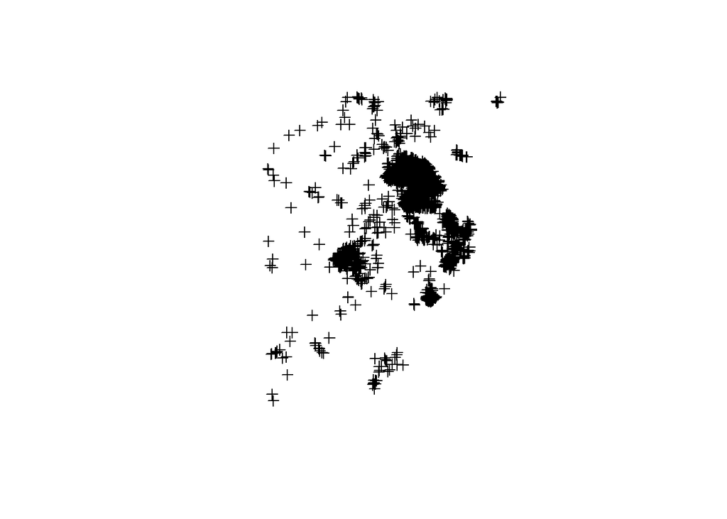

```r
oc_xy <- oc_sale_data[,c("fsid","x","y")]
oc_xy <- subset(oc_xy,!duplicated(fsid))
oc_join <- merge(oc_join,oc_xy,by="fsid")


coordinates(oc_join)=~x+y
proj4string(oc_join)=CRS("+init=epsg:4269")
plot(oc_join)
```

#### To obtain the optimal bandwidth for the `GWR` model, we can use the `gwr.sel` function applied to the same full regression model and set the weighting scheme equal to Gaussian `(gweight=gwr.Gauss)`. I also set `verbose=TRUE` so that I could wath the progress as the function selected the optimal bandwidth.

```r
bwG <- gwr.sel(pr_sq_ft ~ arealotacres + areabuilding +
                 yearbuilt + unitscount + samp_pr05 + factor(tractfp) +
                 factor(fld_zone) + elev_water + yr_vs_start +
                 elev_water:yr_vs_start, data=oc_join,
               gweight=gwr.Gauss, verbose=TRUE)
```

```
## Bandwidth: 12.76001212 CV score: 13924083.3
## Bandwidth: 20.62552053 CV score: 13969353.05
## Bandwidth: 7.898860589 CV score: 13806219.6
## Bandwidth: 4.894503716 CV score: 13540640.14
## Bandwidth: 3.037709054 CV score: 13310147.29
## Bandwidth: 1.890146842 CV score: NA
## Bandwidth: 3.746941505 CV score: 13374271.6
## Bandwidth: 2.599379293 CV score: 13318136.09
## Bandwidth: 2.914802922 CV score: 13307411.05
## Bandwidth: 2.889537039 CV score: 13307278.86
## Bandwidth: 2.879411001 CV score: 13307269.61
## Bandwidth: 2.880728096 CV score: 13307269.38
## Bandwidth: 2.880774734 CV score: 13307269.38
## Bandwidth: 2.880815467 CV score: 13307269.38
## Bandwidth: 2.880774734 CV score: 13307269.38
```

#### Once the bandwidth has been chose, we can estimate our `GWR` model with the `bandwidth` argument being equal to that bandwidth object we created `bwG`. However, the `GWR` function does not recognize traditional interaction approaches so we need to hard code the elevation by year since sale interaction to create a new variable `elv_wat_yr`. After we do that, we can estimate the `GWR` model and save the results to a new object `(gwrG)`.

```r
oc_join$elv_wat_yr <- oc_join$elev_water*oc_join$yr_vs_start

gwrG <- gwr(pr_sq_ft ~ arealotacres + areabuilding +
              yearbuilt + unitscount + samp_pr05 + factor(tractfp) +
              factor(fld_zone) + elev_water + yr_vs_start +
              elv_wat_yr, data=oc_join,
            bandwidth=bwG, gweight=gwr.Gauss)
```

#### Looking at the rsults of the `gwrG` output, we can see that there are a nested set of tables and objects…. we are intersted in the model results in the `SDF` table. In particular, we are interested in the geographically varying model fit `(local R2)`, the geographically varying residuals `(gwr.e)`, the geographic variation in the relationship between elevation and sale price `(elev_water)`, and the geographic variation in the relationship between elevation and sale price over the study period `(elv_wat_yr)`. In each of the plots, we can see significant variation in model fit and the effect of elevation (both as a main effect and in interaction form), however we don’t see a lot of variation in residuals which is a product of the better fitting local models.

```r
gwrG
```

```
## Call:
## gwr(formula = pr_sq_ft ~ arealotacres + areabuilding + yearbuilt +
##     unitscount + samp_pr05 + factor(tractfp) + factor(fld_zone) +
##     elev_water + yr_vs_start + elv_wat_yr, data = oc_join, bandwidth = bwG,
##     gweight = gwr.Gauss)
## Kernel function: gwr.Gauss
## Fixed bandwidth: 2.880774734
## Summary of GWR coefficient estimates at data points:
##                                      Min.        1st Qu.         Median
## X.Intercept.               -4.2842025e+03  1.2194883e+02  3.4104531e+02
## arealotacres               -7.9895053e-01  2.3969909e+00  3.0369532e+00
## areabuilding               -2.2135774e-02 -3.1627122e-03 -2.7983940e-03
## yearbuilt                  -8.8256344e-01 -2.0576419e-01 -1.4839089e-01
## unitscount                 -1.2761771e+01 -8.1922507e+00 -5.3955395e+00
## samp_pr05                  -2.9354978e-01  3.0464289e-01  3.1736656e-01
## factor.tractfp.24047950600 -2.2284931e+01  1.6226522e+01  1.9146061e+01
## factor.tractfp.24047950700 -2.2362900e+01  1.6247476e+01  2.2323126e+01
## factor.tractfp.24047950800 -4.5536903e+01  1.6951717e+01  1.8703035e+01
## factor.tractfp.24047950900 -5.7696024e+01 -1.7798601e+01 -2.9775421e+00
## factor.tractfp.24047951000 -4.1285510e+01  1.2824412e+00  1.8243410e+01
## factor.tractfp.24047951100 -7.0297540e+00  1.4790711e+01  1.5492755e+01
## factor.tractfp.24047951200 -4.2211290e+01 -2.7917507e+01 -2.2350955e+01
## factor.tractfp.24047951700  1.5053354e+00  2.3203465e+01  2.6475805e+01
## factor.fld_zone.AE         -7.3352559e+01  8.4102581e+01  1.0161402e+02
## factor.fld_zone.X          -6.6929549e+01  6.8448040e+01  7.7649749e+01
## elev_water                 -2.0237960e+00 -5.8811608e-01 -4.7974620e-01
## yr_vs_start                -1.3002192e+01 -5.9933952e+00 -5.8427539e+00
## elv_wat_yr                 -2.7433227e-02  1.7540402e-02  2.4571598e-02
##                                   3rd Qu.           Max.    Global
## X.Intercept.                4.5036459e+02  1.7162628e+03 179.67807
## arealotacres                3.9550657e+00  1.1080305e+01   0.81521
## areabuilding               -2.3321242e-03  6.4764352e-04  -0.00201
## yearbuilt                  -3.8912434e-02  2.1632963e+00  -0.06894
## unitscount                 -1.9918937e+00  8.3853700e+01   3.01284
## samp_pr05                   3.3789534e-01  7.8810531e-01   0.35246
## factor.tractfp.24047950600  2.1028899e+01  2.9497184e+01  19.46098
## factor.tractfp.24047950700  2.4492626e+01  5.2346398e+01  20.24250
## factor.tractfp.24047950800  1.9801770e+01  1.8401151e+02  15.35436
## factor.tractfp.24047950900  6.0781893e+00  1.2725899e+02  -0.33849
## factor.tractfp.24047951000  3.0043699e+01  2.5332098e+02  14.39185
## factor.tractfp.24047951100  1.6134768e+01  2.2519575e+01  16.16588
## factor.tractfp.24047951200 -1.9090355e+01  5.8058887e+01 -13.62672
## factor.tractfp.24047951700  3.0265962e+01  1.2324887e+02  29.12687
## factor.fld_zone.AE          1.0567323e+02  1.5046245e+02  86.39344
## factor.fld_zone.X           8.2532975e+01  9.8127100e+01  65.02927
## elev_water                 -3.5301997e-01  3.6995811e-01  -0.45166
## yr_vs_start                -5.7321486e+00 -4.2123488e-02  -5.95639
## elv_wat_yr                  3.2016192e-02  1.3552991e-01   0.03870
```

```r
names(gwrG)
```

```
##  [1] "SDF"       "lhat"      "lm"        "results"   "bandwidth"
##  [6] "adapt"     "hatmatrix" "gweight"   "gTSS"      "this.call"
## [11] "fp.given"  "timings"
```

```r
names (gwrG$SDF)
```

```
##  [1] "sum.w"                      "(Intercept)"
##  [3] "arealotacres"               "areabuilding"
##  [5] "yearbuilt"                  "unitscount"
##  [7] "samp_pr05"                  "factor(tractfp)24047950600"
##  [9] "factor(tractfp)24047950700" "factor(tractfp)24047950800"
## [11] "factor(tractfp)24047950900" "factor(tractfp)24047951000"
## [13] "factor(tractfp)24047951100" "factor(tractfp)24047951200"
## [15] "factor(tractfp)24047951700" "factor(fld_zone)AE"
## [17] "factor(fld_zone)X"          "elev_water"
## [19] "yr_vs_start"                "elv_wat_yr"
## [21] "gwr.e"                      "pred"
## [23] "localR2"
```

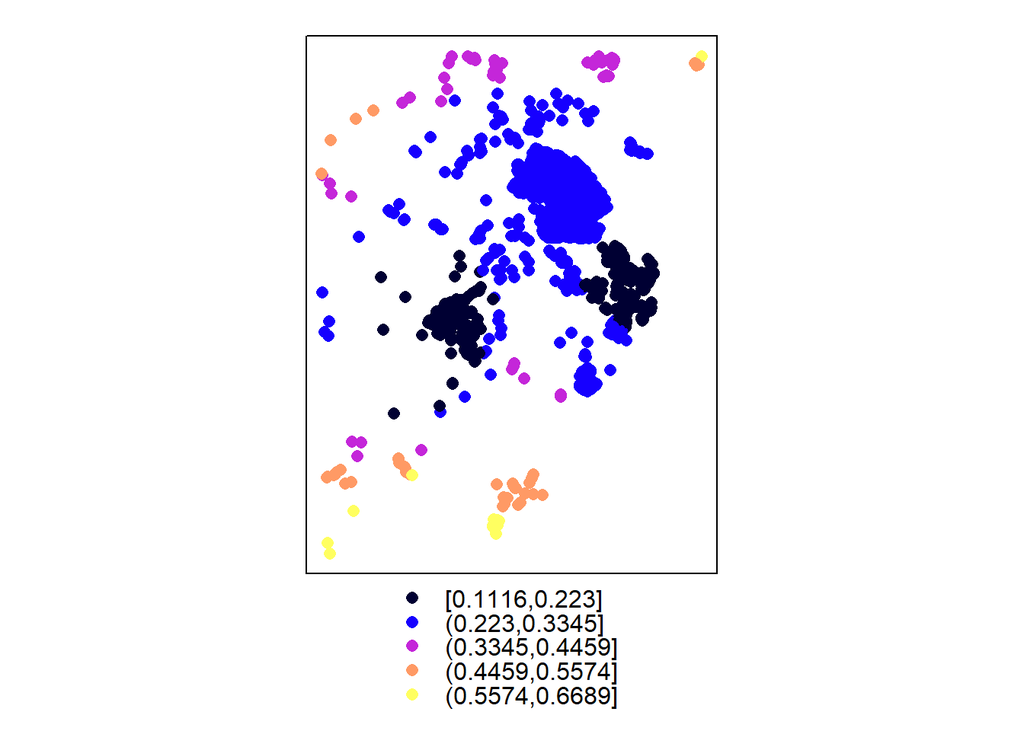

```r
spplot(gwrG$SDF, "localR2")
```

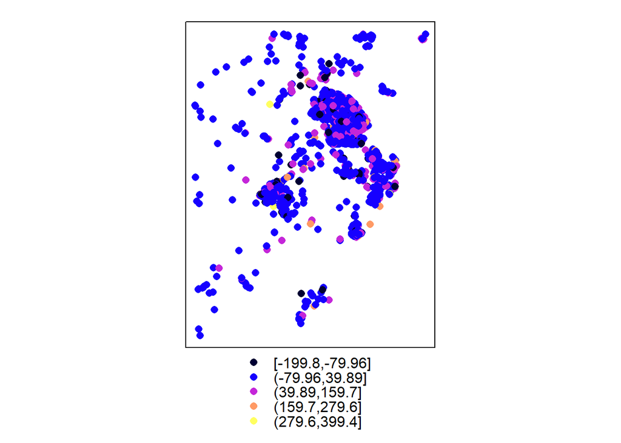

```r
spplot(gwrG$SDF, "gwr.e")
```

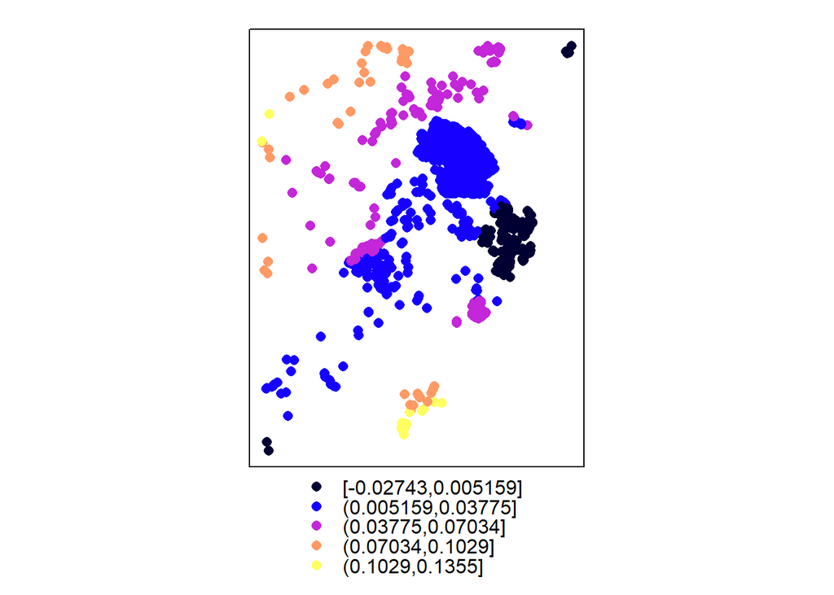

```r
spplot(gwrG$SDF, "elv_wat_yr")
```

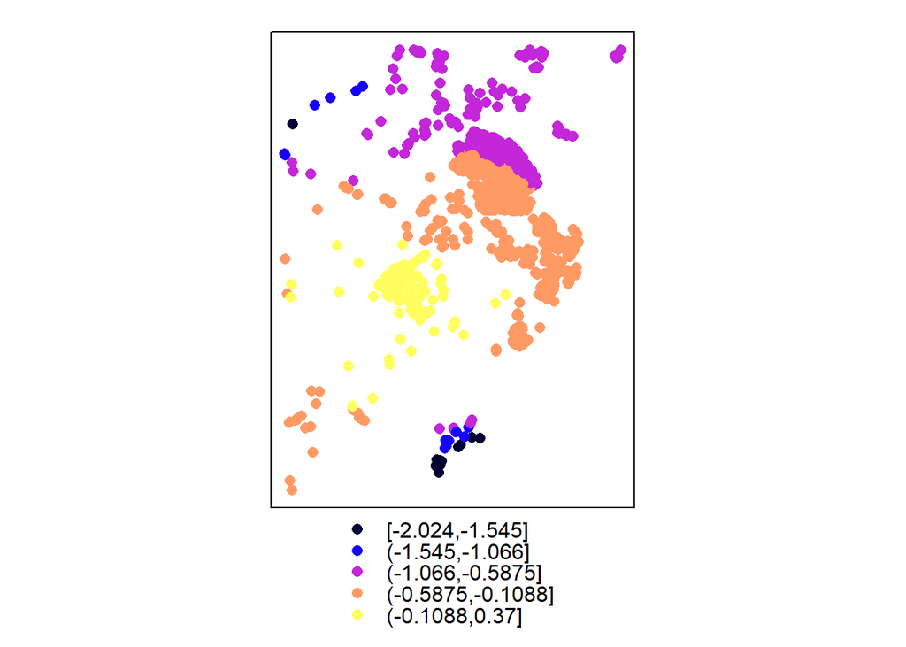

```r
spplot(gwrG$SDF, "elev_water")
```

#### Finally, I want to map these results using `GGplot` so I require the `ggplot2` package. Also, to map the data I must also conver the data to a dataframe which I do with the `as.data.frame` function to convert the `gwrG$SDF` table to create the `gwr_reslts` object. One thing to note is that when using `GGplot` in the plotting points (in relation to polygons) you don’t have to `fortify` the file. The first object I create is a `map` of just the points to make sure that I have the data setup properly. To create the map, I use an empty `ggplot()` function `+` the `geom_point` function with the map `data` and aesthetics `(aes)` set to map the points from the `gw_results` object by longitude `(x)` and latitude `(y)`.

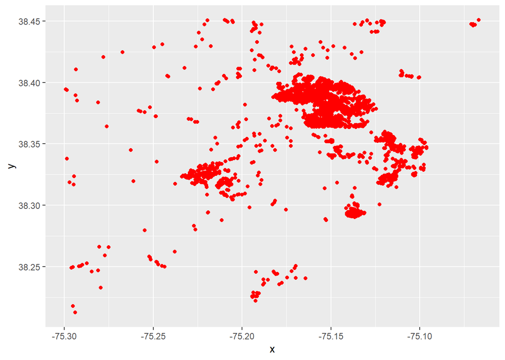

```r
require(ggplot2)
gwr_results <- as.data.frame(gwrG$SDF)


map <- ggplot() + geom_point(data=gwr_results,
             aes(x=x, y=y),
             color="red")
map
```

#### Since the data are set up properly to map, I am going to clean up the image by mapping the same object, with the same latitude and longitude, but specifying that this map vary the colors of the points by the variation in model fit `(color = localR2)`. Futhermore, I want to set the labels of the x-axis and y-axis to empty `(x="", y="")` and set the title of the plot to `Variation in Local R-Square`. In the next chunk of code, I am removing the axis tick marks and text on both axes and adjusting the plot title to be `bold` faced, in the middle of the plot horizontally `(hjust=0.5)`, at the bottom of the plot vertically `(vjust=-132)`, and of font size 12 `(size=12)`. In terms of the legend, I added the title “Model Fit” and the color scheme to range from light beige to dark red `(colours=c( "#f9f3c2","#660000"))`. Finally, I placed the legend in the bottom right had corner `(legend.position = c(0.90,0.23))` and set the text of both the legend title and the scale text to font size 7.

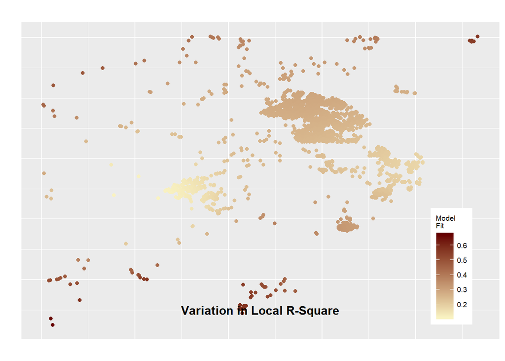

```r
map2 <- ggplot() +
  geom_point(data=gwr_results, aes(x=x, y=y, color=localR2)) +
  labs(x="", y="", title = "Variation in Local R-Square") +
  theme(axis.ticks.y = element_blank(),axis.text.y = element_blank(),
        axis.ticks.x = element_blank(),axis.text.x = element_blank(),
        plot.title = element_text(face="bold", hjust=0.5, vjust=-132, size=12)) +
  scale_colour_gradientn("Model\nFit",
                         colours=c( "#f9f3c2","#660000")) +
  theme(legend.position = c(0.90,0.23),
        legend.text=element_text(size=7),
        legend.title=element_text(size=7))

map2
```

#### Following the same logic, I mapped the residuals, the effect of elevation, and the effect of elevation over time.

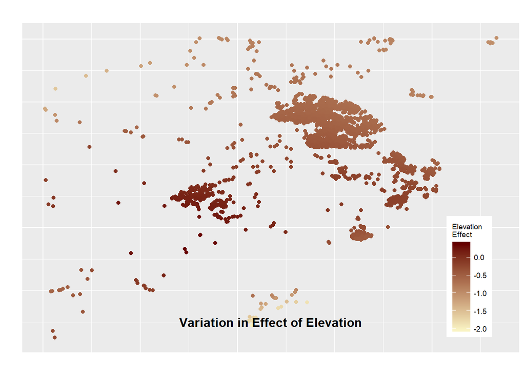

```r
map3 <- ggplot() +
  geom_point(data=gwr_results, aes(x=x, y=y, color=elev_water)) +
  labs(x="", y="", title = "Variation in Effect of Elevation") +
  theme(axis.ticks.y = element_blank(),axis.text.y = element_blank(),
        axis.ticks.x = element_blank(),axis.text.x = element_blank(),
        plot.title = element_text(face="bold", hjust=0.5, vjust=-132, size=12)) +
  scale_colour_gradientn("Elevation\nEffect",
                         colours=c( "#f9f3c2","#660000")) +
  theme(legend.position = c(0.90,0.23),
        legend.text=element_text(size=7),
        legend.title=element_text(size=7))

map3
```

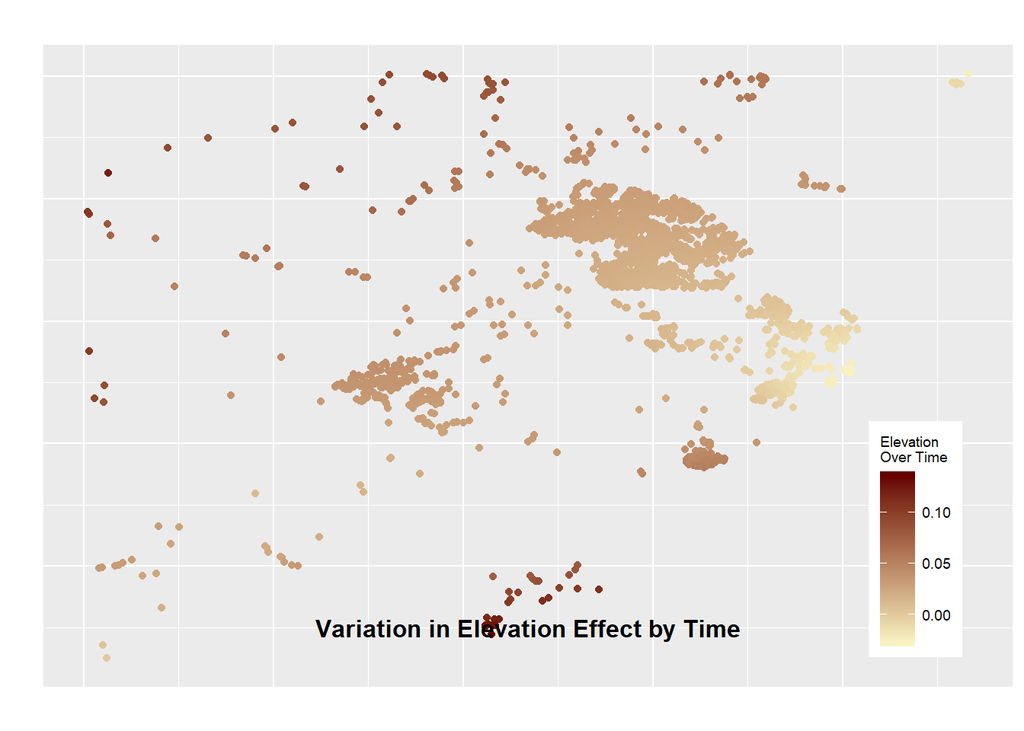

```r
map4 <- ggplot() +
  geom_point(data=gwr_results, aes(x=x, y=y, color=elv_wat_yr)) +
  labs(x="", y="", title = "Variation in Elevation Effect by Time") +
  theme(axis.ticks.y = element_blank(),axis.text.y = element_blank(),
        axis.ticks.x = element_blank(),axis.text.x = element_blank(),
        plot.title = element_text(face="bold", hjust=0.5, vjust=-132, size=12)) +
  scale_colour_gradientn("Elevation\nOver Time",
                         colours=c( "#f9f3c2","#660000")) +
  theme(legend.position = c(0.90,0.23),
        legend.text=element_text(size=7),
        legend.title=element_text(size=7))

map4
```

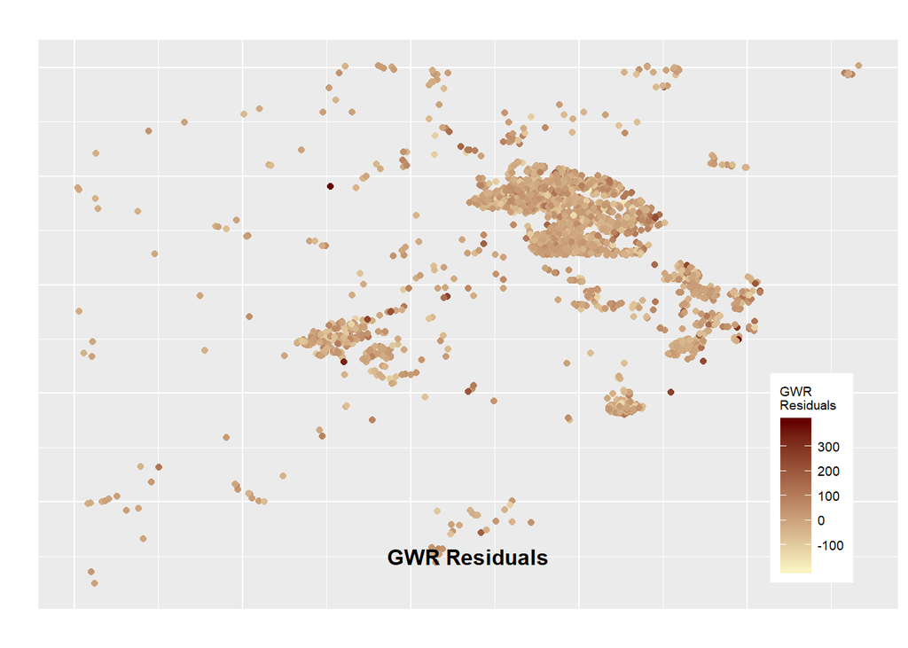

```r
map5 <- ggplot() +
  geom_point(data=gwr_results, aes(x=x, y=y, color=gwr.e)) +
  labs(x="", y="", title = "GWR Residuals") +
  theme(axis.ticks.y = element_blank(),axis.text.y = element_blank(),
        axis.ticks.x = element_blank(),axis.text.x = element_blank(),
        plot.title = element_text(face="bold", hjust=0.5, vjust=-132, size=12)) +
  scale_colour_gradientn("GWR\nResiduals",
                         colours=c( "#f9f3c2","#660000")) +
  theme(legend.position = c(0.90,0.23),
        legend.text=element_text(size=7),
        legend.title=element_text(size=7))

map5
```

#### For our final lab deliverable, lets take these 4 maps and organize them on a single map document. To do that, I required the package `ggpubr` and used the function `ggarrange` to organize the 4 maps into 2 rows `(ggarrange(map2, map5, map3, map4, ncol=2, nrow=2))` and used the `annotate_figure` funcation to add a Figure Title. The size of the plot area throws off the location of the subtitles and legends so I converted mine to PDF to produce the full map image at the end of this document. Use this as your lab 7 deliverable… and have a good spring recess.

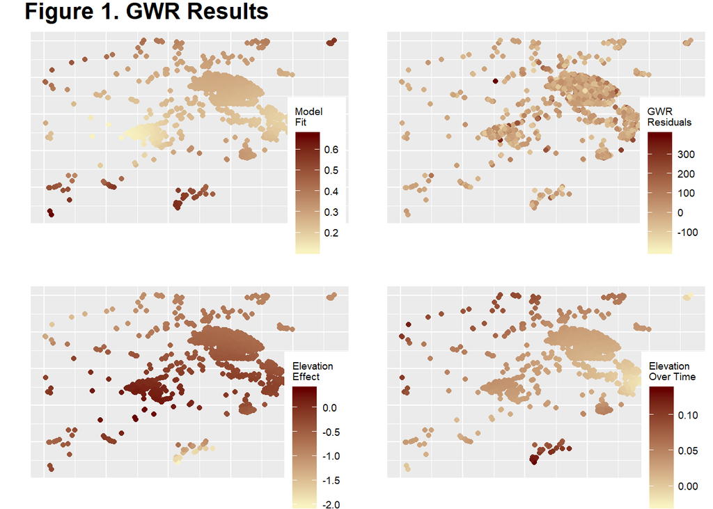

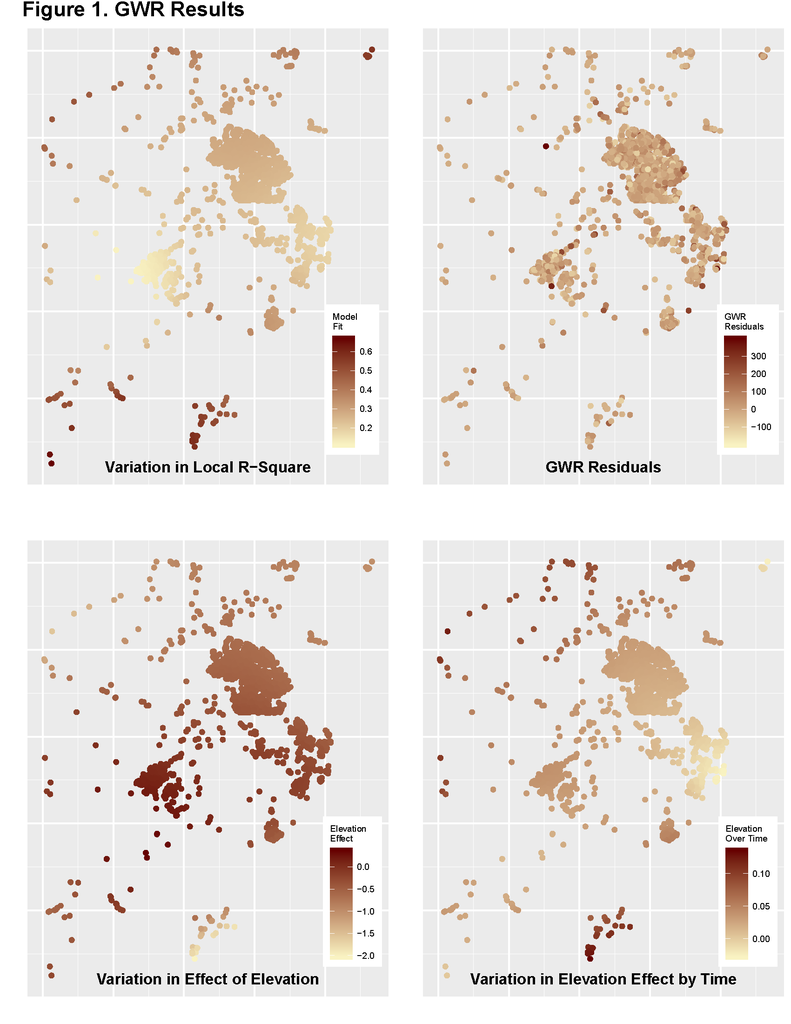

```r
#install.packages("ggpubr")
require(ggpubr)

multi <- ggarrange(map2, map5, map3, map4, ncol=2, nrow=2)
multi <- annotate_figure(multi, fig.lab = "Figure 1. GWR Results",
                         fig.lab.pos = "top.left", fig.lab.size = 16,
                         fig.lab.face = "bold")
multi
```